# Describe exchange rate and volume

# Level

## Normal distribution

### Exchange rate

#### BCH

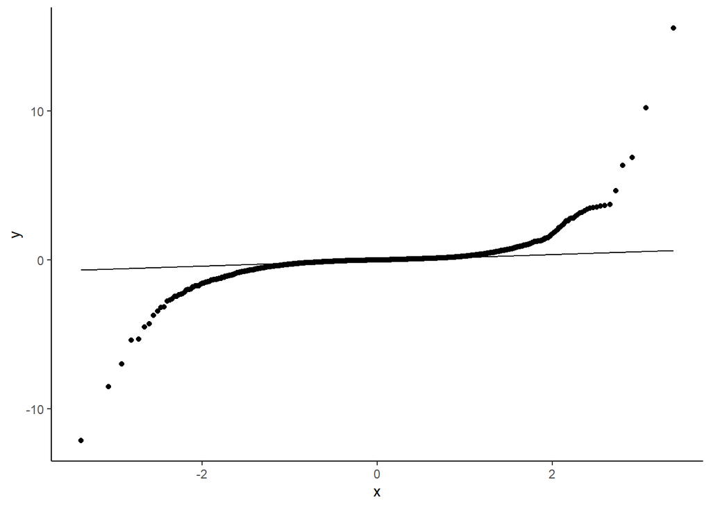

#### BSV

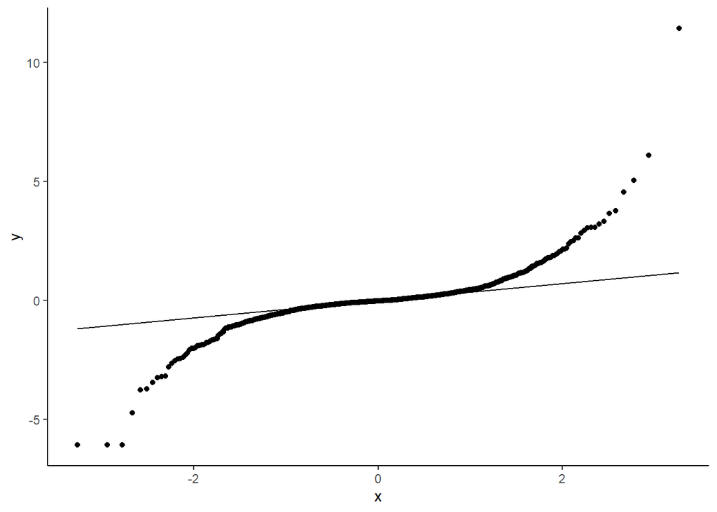

#### BTC

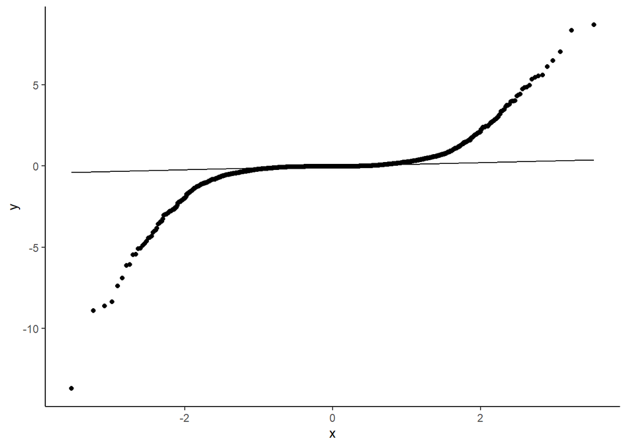

### Transaction volume

#### BCH

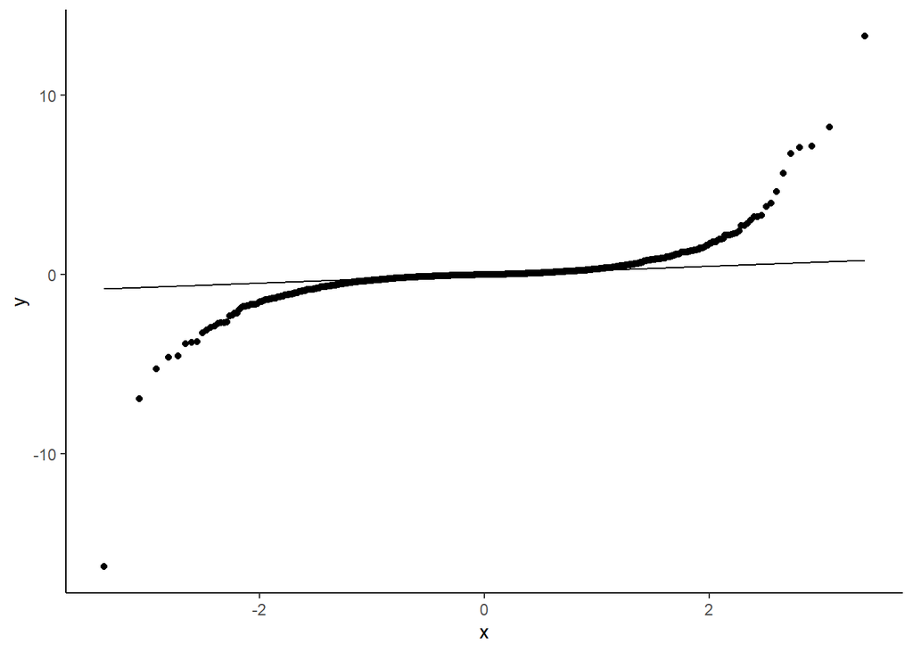

#### BSV

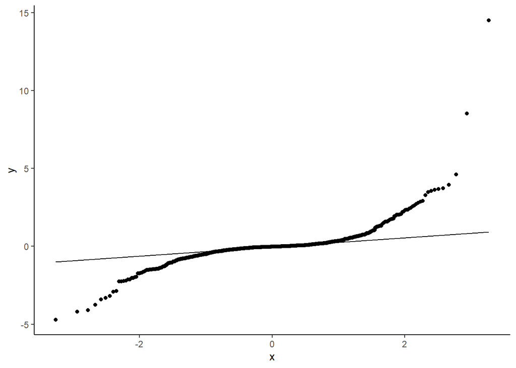

#### BTC

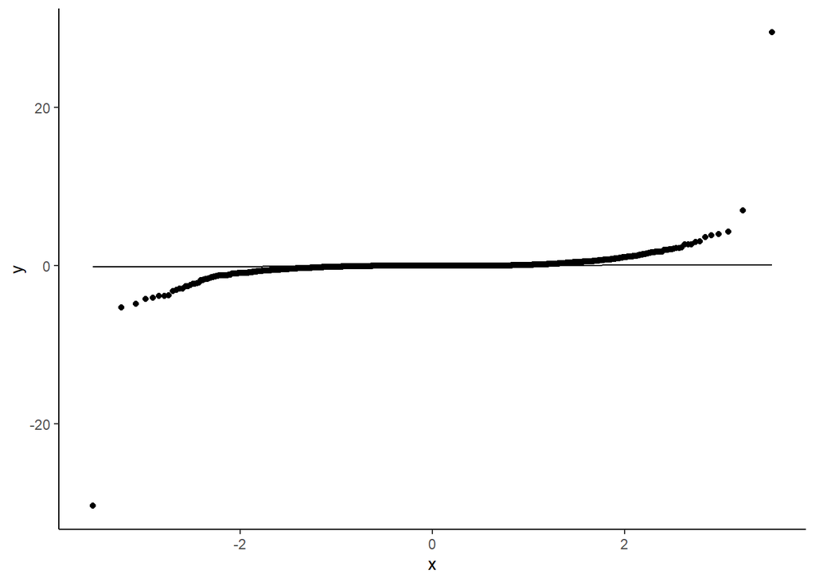

## t distribution

### Exchange rate

$start.arg $start.arg$df [1] 2

$fix.arg NULL

$start.arg $start.arg$df [1] 2

$fix.arg NULL

$start.arg $start.arg$df [1] 2

$fix.arg NULL

#### BCH

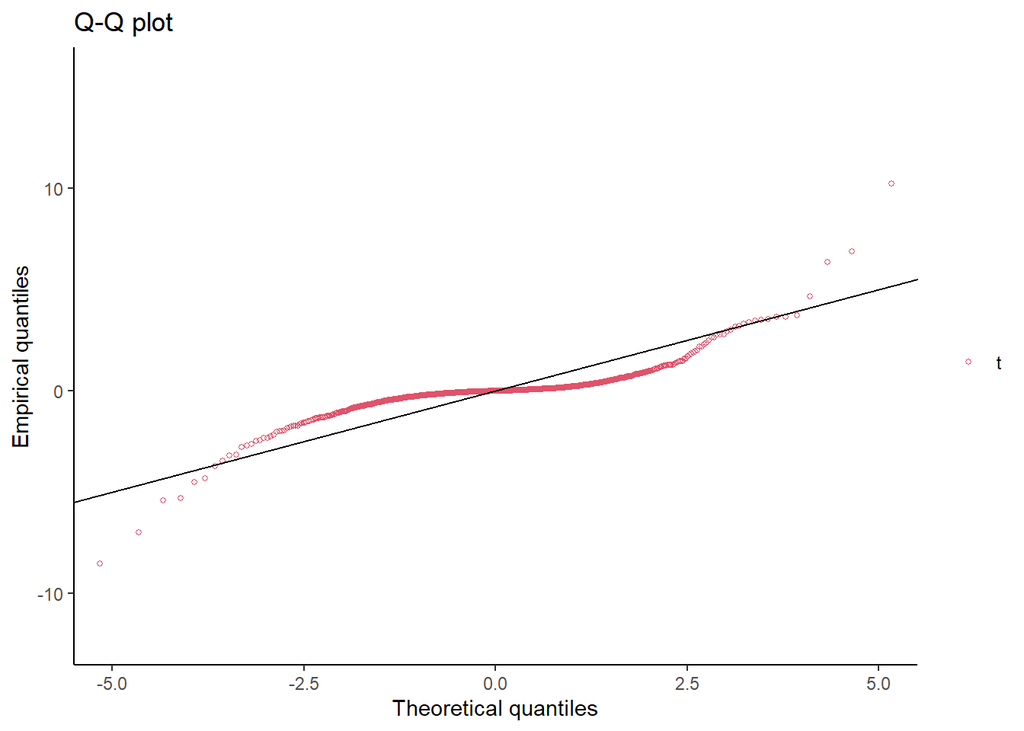

#### BSV

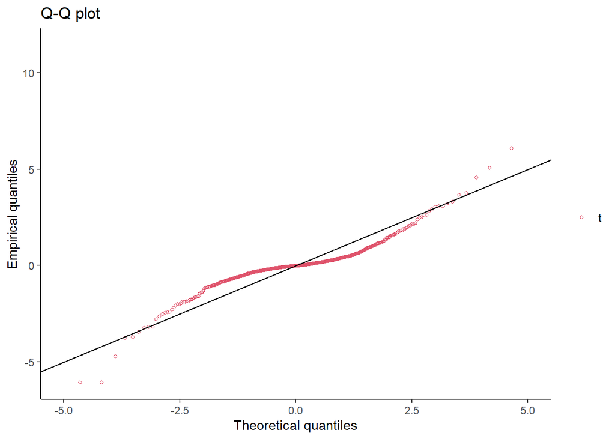

#### BTC

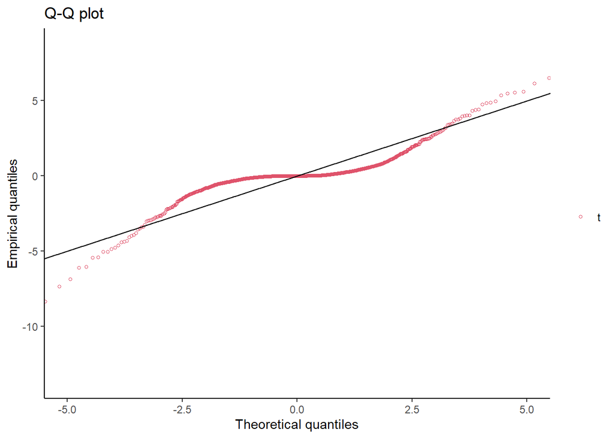

### Transaction volume

$start.arg $start.arg$df [1] 2

$fix.arg NULL

$start.arg $start.arg$df [1] 2

$fix.arg NULL

$start.arg $start.arg$df [1] 2

$fix.arg NULL

#### BCH

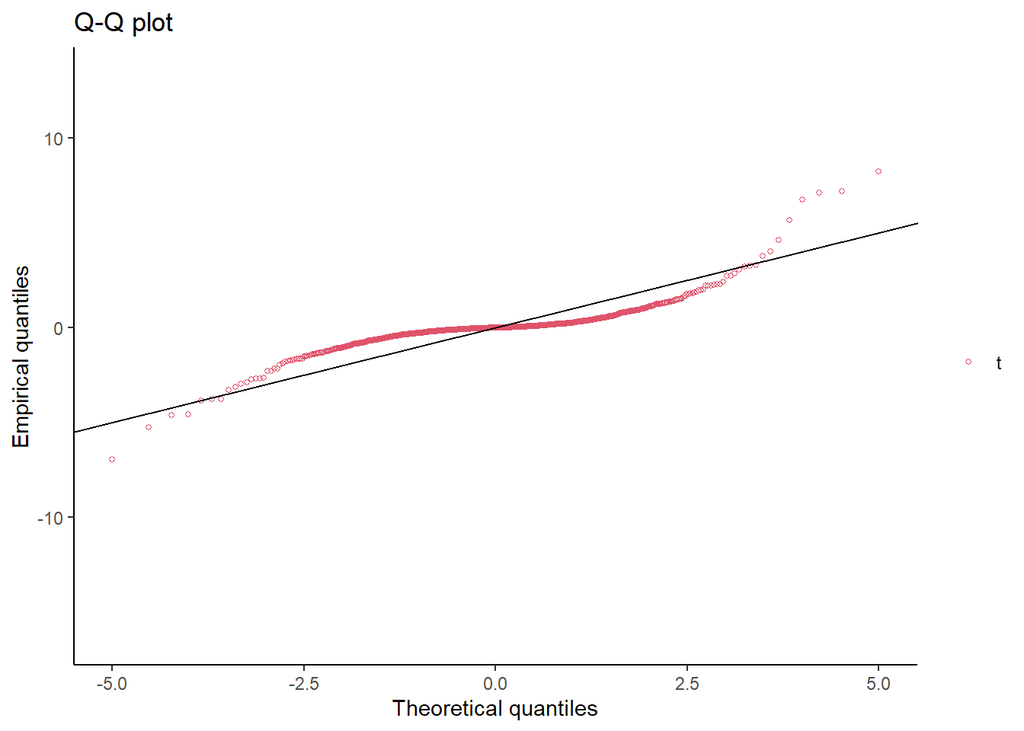

#### BSV

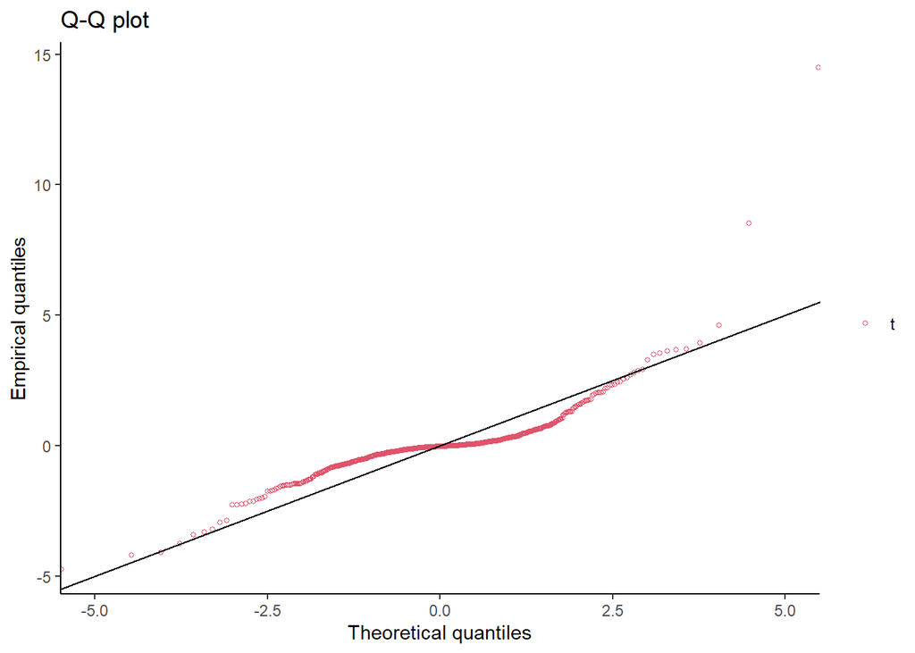

#### BTC

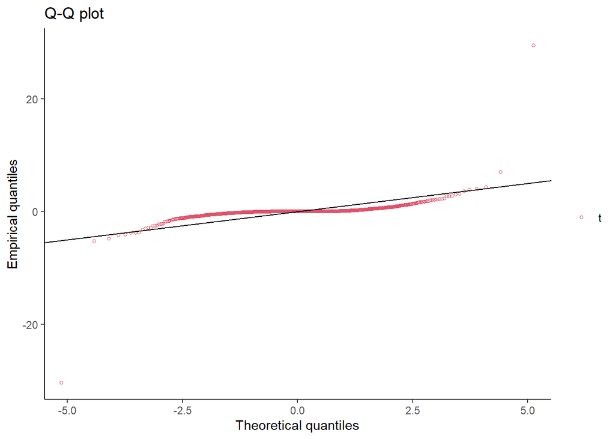

## Cauchy distribution

### Exchange rate

$start.arg $start.arg$location [1] -0.005768224

$start.arg$scale [1] 0.1305429

$fix.arg NULL

$start.arg $start.arg$location [1] -0.02122378

$start.arg$scale [1] 0.2447874

$fix.arg NULL

$start.arg $start.arg$location [1] -0.02544119

$start.arg$scale [1] 0.07497609

$fix.arg NULL

#### BCH

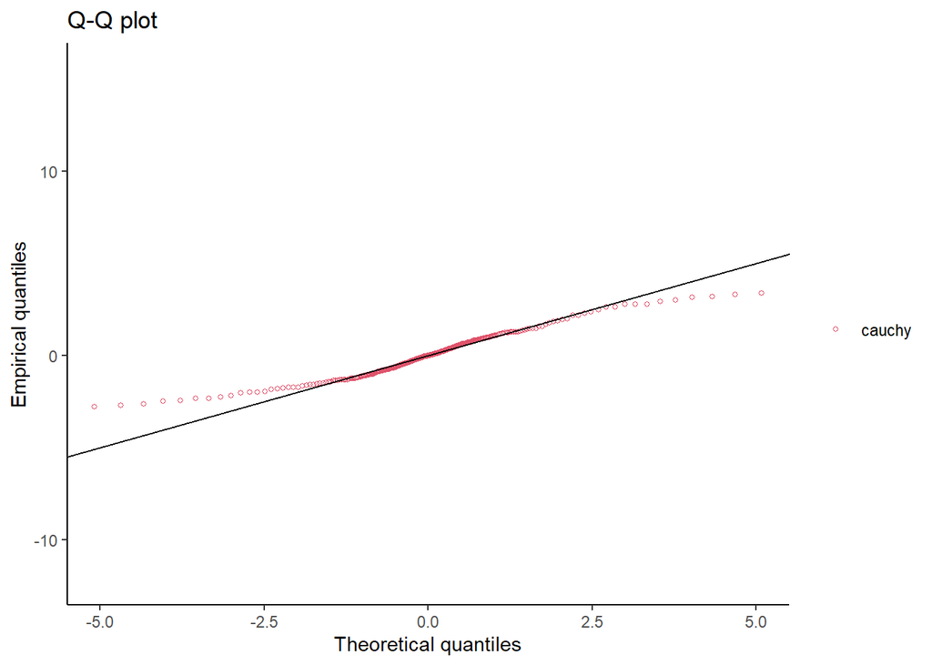

#### BSV

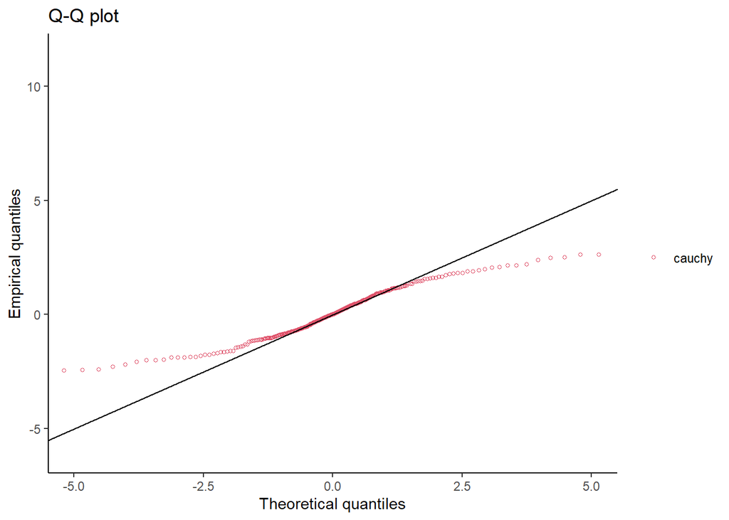

#### BTC

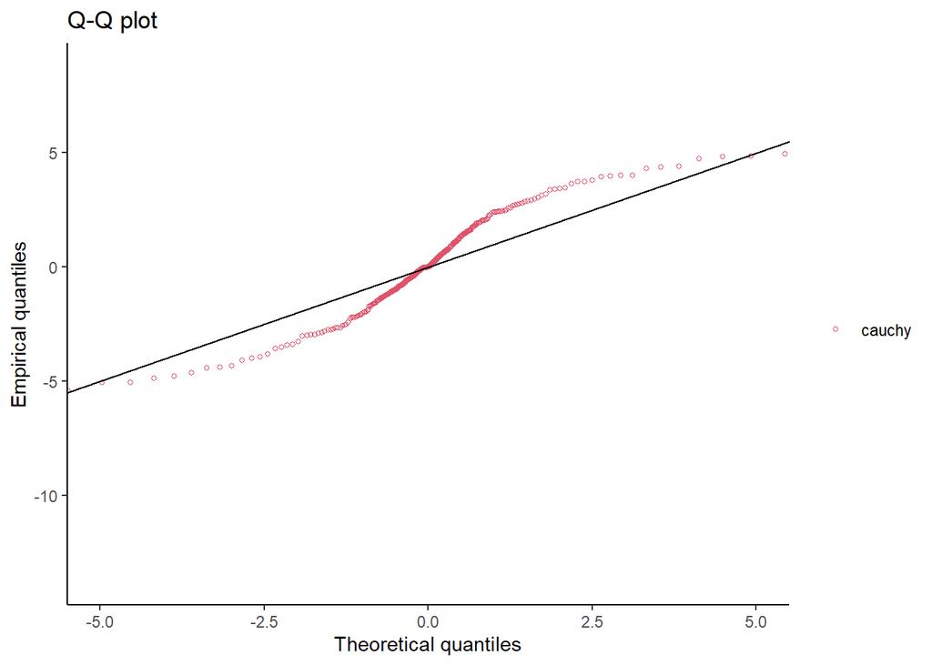

### Transaction volume

$start.arg $start.arg$location [1] -0.01447356

$start.arg$scale [1] 0.1595175

$fix.arg NULL

$start.arg $start.arg$location [1] -0.02540491

$start.arg$scale [1] 0.1998443

$fix.arg NULL

$start.arg $start.arg$location [1] -0.002038925

$start.arg$scale [1] 0.02729582

$fix.arg NULL

#### BCH

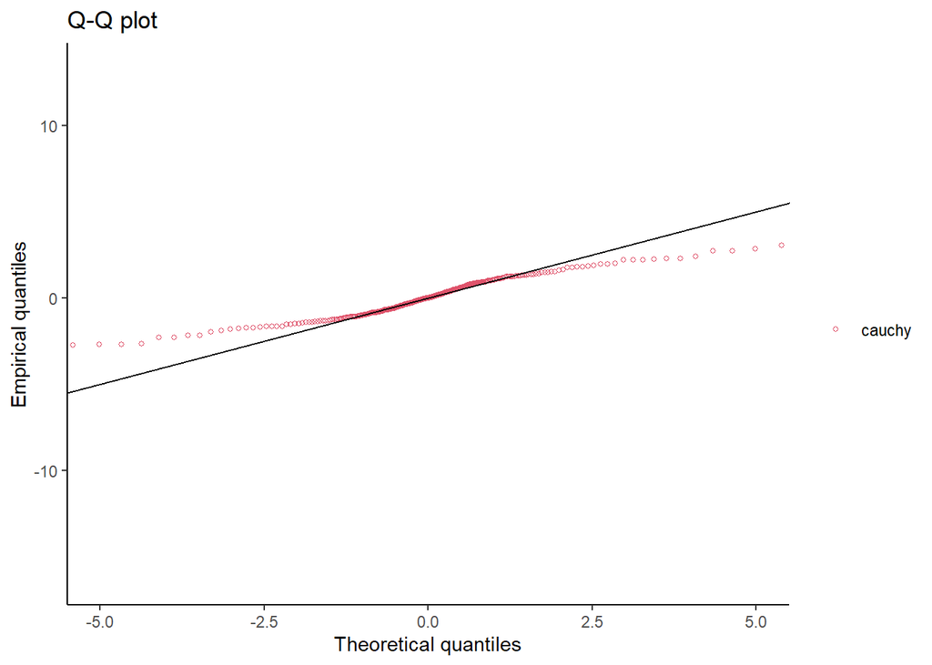

#### BSV

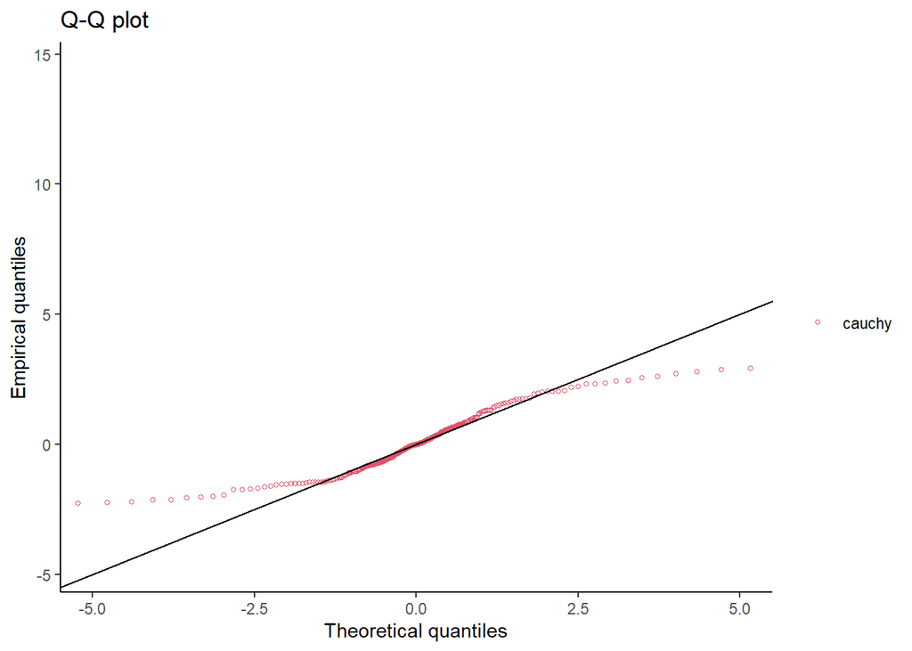

#### BTC

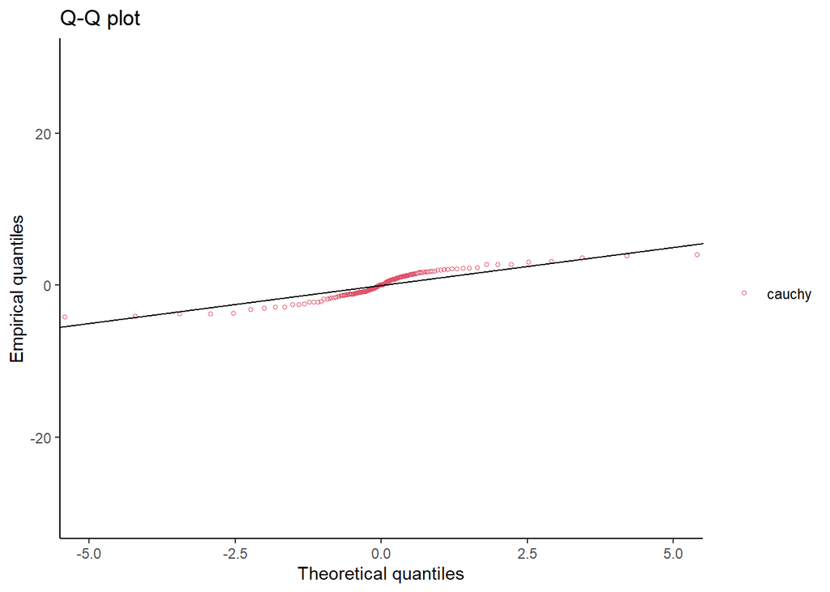

# Log

## Normal distribution

### Exchange rate

#### BCH

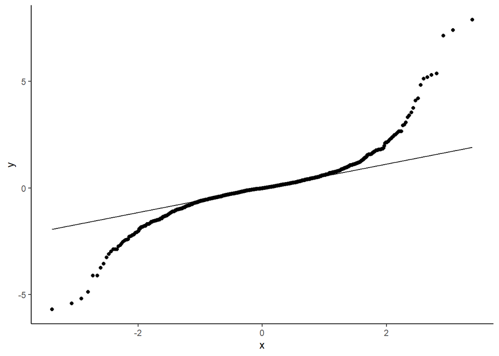

#### BSV

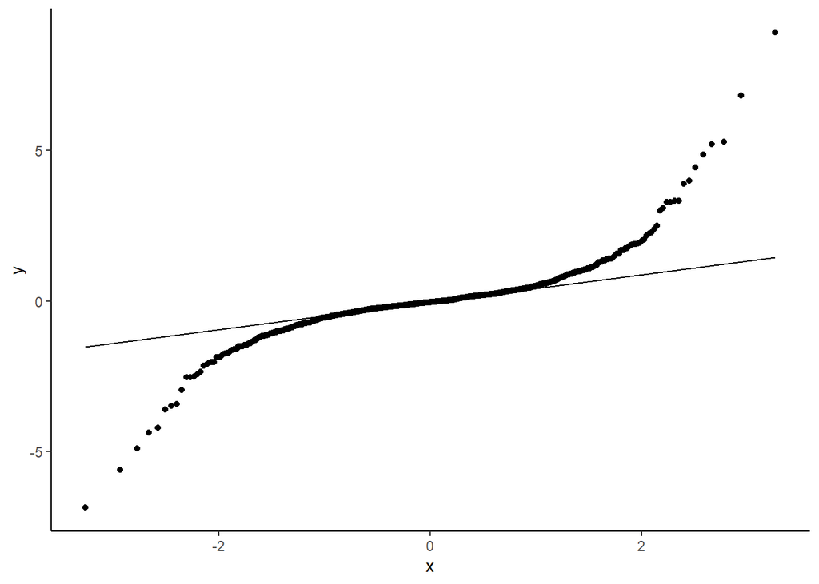

#### BTC

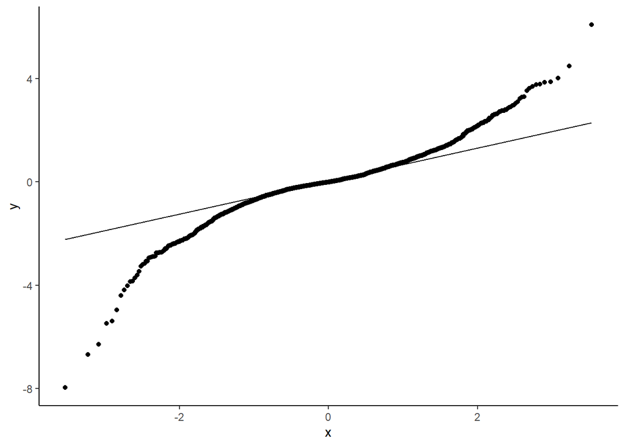

### Transaction volume

#### BCH

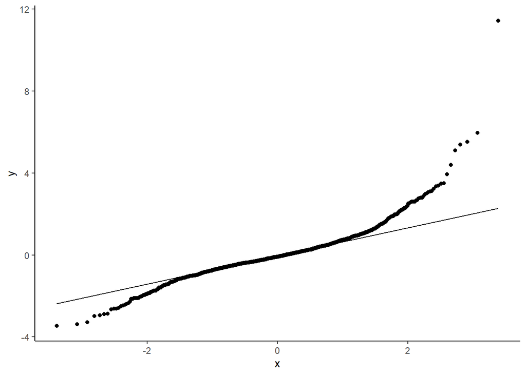

#### BSV

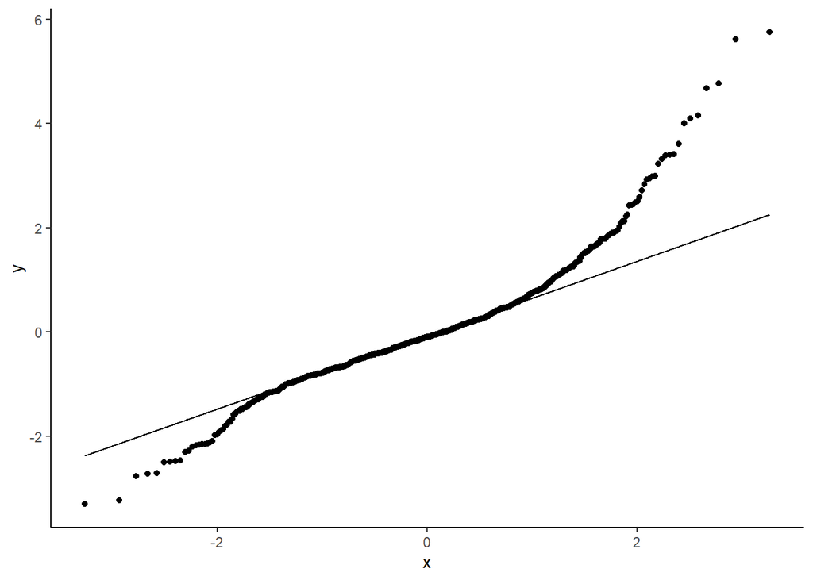

#### BTC

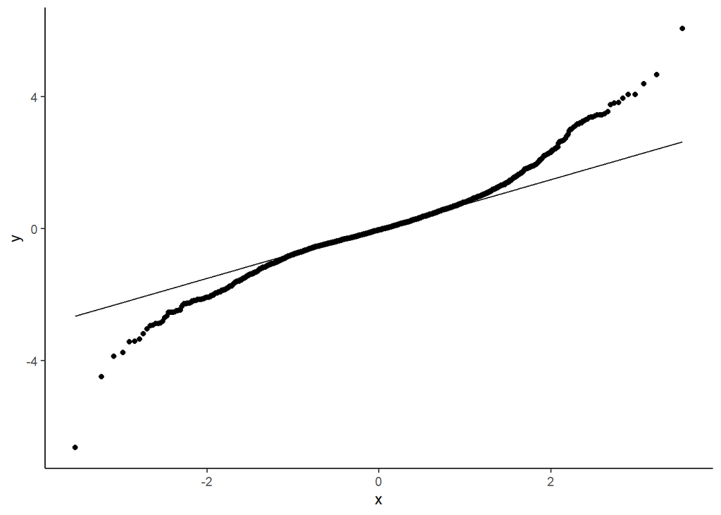

## t distribution

### Exchange rate

$start.arg $start.arg$df [1] 10

$fix.arg NULL

$start.arg $start.arg$df [1] 10

$fix.arg NULL

$start.arg $start.arg$df [1] 10

$fix.arg NULL

#### BCH

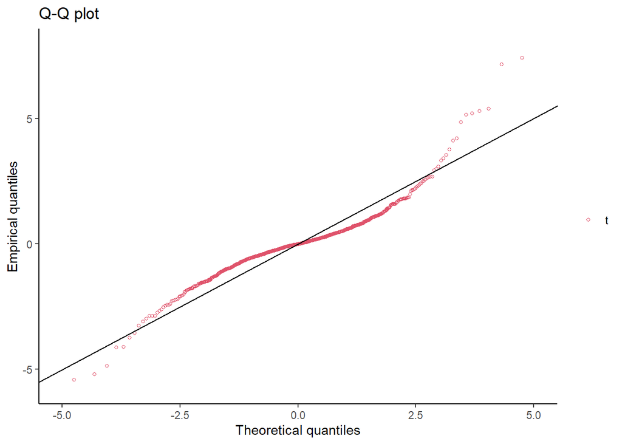

#### BSV

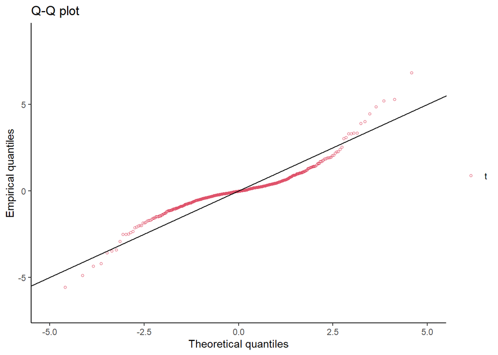

#### BTC

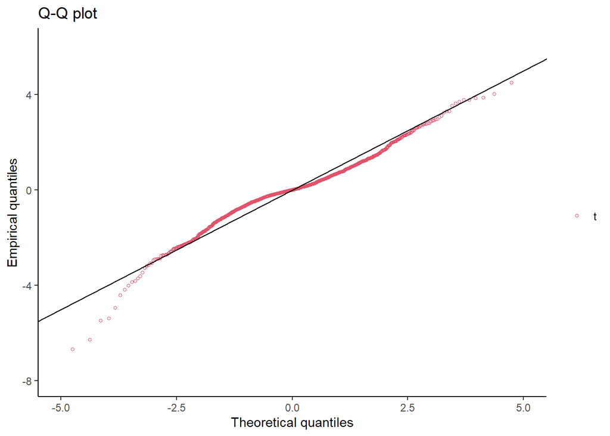

### Transaction volume

$start.arg $start.arg$df [1] 10

$fix.arg NULL

$start.arg $start.arg$df [1] 10

$fix.arg NULL

$start.arg $start.arg$df [1] 10

$fix.arg NULL

#### BCH

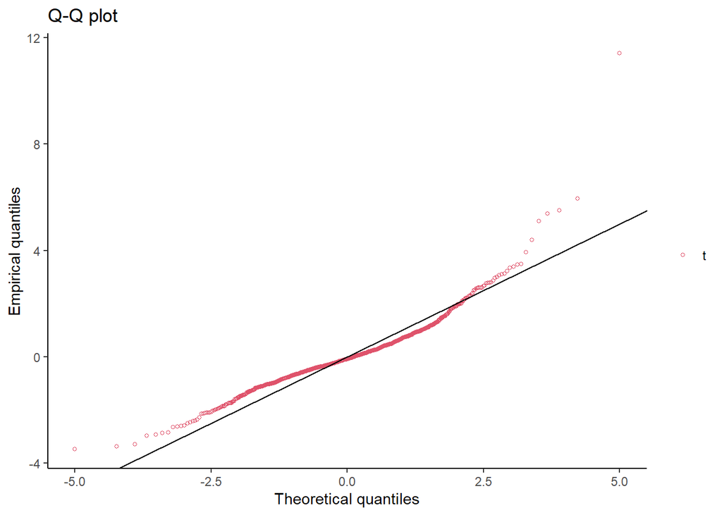

#### BSV

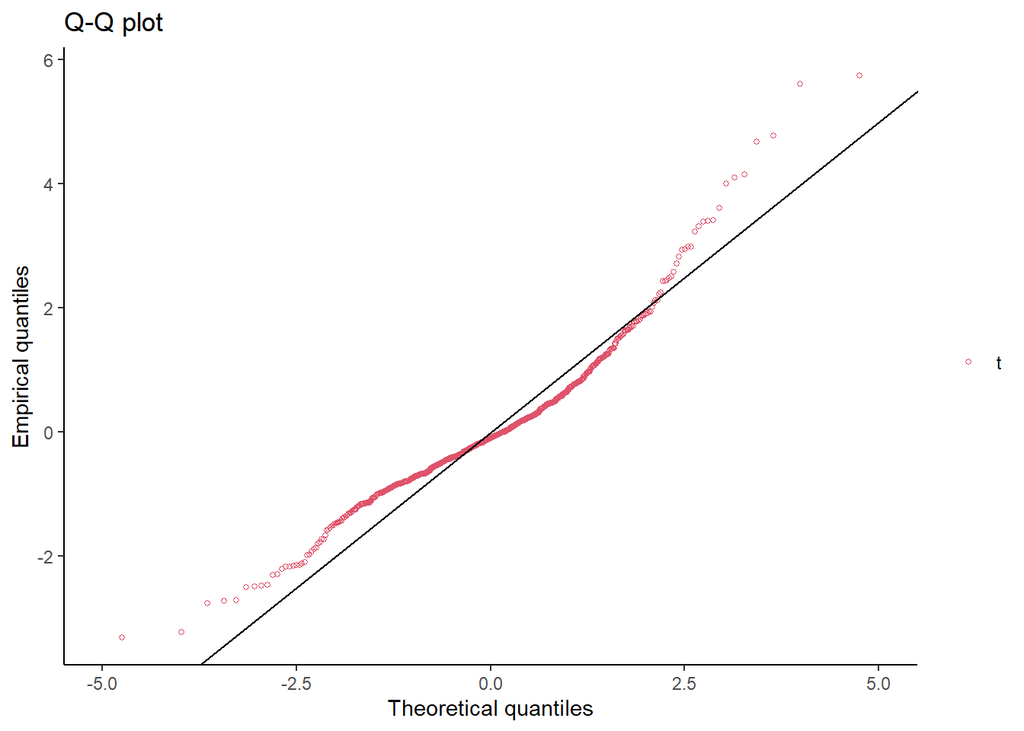

#### BTC

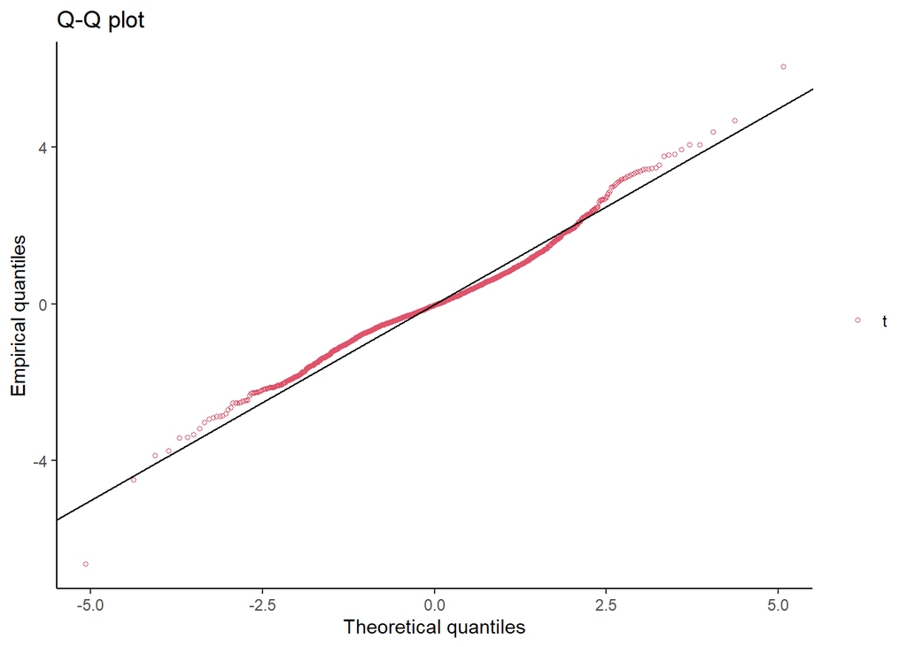

## Cauchy distribution

### Exchange rate

$start.arg $start.arg$location [1] -0.01864282

$start.arg$scale [1] 0.3824877

$fix.arg NULL

$start.arg $start.arg$location [1] -0.03437632

$start.arg$scale [1] 0.307338

$fix.arg NULL

$start.arg $start.arg$location [1] -0.004322158

$start.arg$scale [1] 0.4297807

$fix.arg NULL

#### BCH

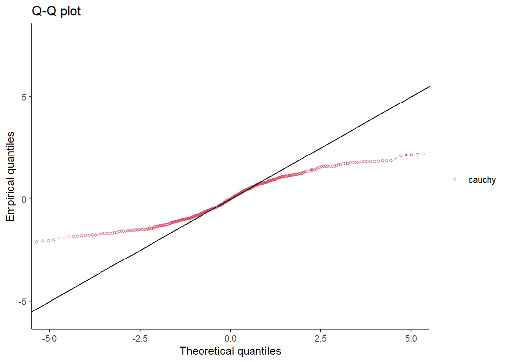

#### BSV

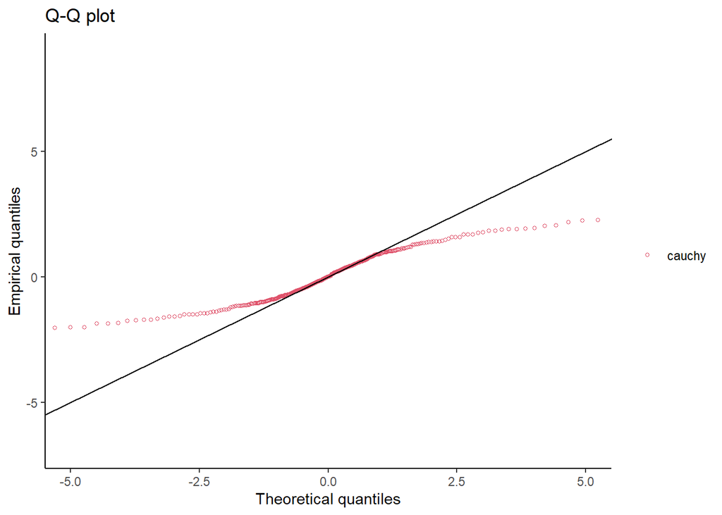